# Análisis Bootstrap, Bagging y Modelos Predictivos aplicados a problemas de control de inventario con degradación de productos.

Author

Cristóbal Pérez González.

# Introducción.

En esta presentación se aprendera a aplicar **técnicas de remuestreo (Bootstrap)** y **Bagging (Bootstrap Aggregating)** en problemas de control de inventario con degradación de productos.

Antes de entrar al código, recuerde los siguientes conceptos:

- **Bootstrap:** Técnica estadística que crea múltiples “nuevas muestras” a partir de los datos originales, extrayendo observaciones **con reemplazo**. Lo cual permite medir la **incertidumbre** de los estimadores.

La idea básica es:

1.- Tomar la muestra original.

2.- Generar muchas remuestras con reemplazo (es decir, podemos repetir los mismos datos).

3.- Calcular el estadístico de interés en cada remuestra.

4.- Analizar la distribución de estos estadísticos para ver su variabilidad y construir intervalos de confianza.

- **Intervalo de confianza Bootstrap:** Rango de valores donde es muy probable que se encuentre el verdadero parámetro poblacional (ej. la media).
- **Bagging:** Técnica de aprendizaje máquina donde se entrenan muchos modelos en diferentes remuestras bootstrap y luego **se promedian** sus predicciones en el caso de regresion y se **vota** en el caso de calsificacion, con esto se reducela varianza y mejora la estabilidad de los modelos.

## Importación de librerías

Primero se carga todas las librerías necesarias para generar datos, manipularlos, entrenar modelos y graficar resultados.

```julia
using Pkg

# Lista de paquetes a instalar
packages = [
    "Distributions",
    "DataFrames",
    "GLM",
    "DecisionTree",
    "Plots",
    "Statistics",
    "StatsPlots",
    "Random",
    "PrettyTables"
]

# Instalar todos los paquetes
for package in packages
    println("Instalando $package...")
    Pkg.add(package)
end
using Distributions   # Para generar datos sintéticos
using DataFrames      # Para manejar datos tabulares
using PrettyTables    # Para tener una mejor visualiación del Dataframe
using GLM             # Para modelos de regresión lineal y logística
using DecisionTree    # Para árboles de decisión y Bagging (Random Forest)
using Plots           # Para visualización
using Statistics      # Para funciones estadísticas básicas
using StatsPlots      # Para gráficos estadísticos avanzados
using Random          # Para el control de semillas para reproducibilidad

# Se fija una semilla para que los resultados sean reproducibles
Random.seed!(123)
```

[output not shown]

[output cut: 470 more lines]

[output not shown]

```
TaskLocalRNG()
```

# PARTE A: FUNDAMENTOS DE BOOSTRAP.

## 1.- Re-muestreo con reemplazo.

El **Bootstrap** parte de la idea de que, aunque solo se tenga una **muestra**, se puede generar muchas más extrayendo valores con **reemplazo**.

Se considera una muestra pequeña de niveles de inventario perdidos por degradación:

```julia
inventario_perdido = [3, 5, 7]
media_original = mean(inventario_perdido)
println("Muestra original: $inventario_perdido")
println("Media original: $media_original \n")
```

```
Muestra original: [3, 5, 7]
Media original: 5.0
```

Se genera 5 re-muestreos con reemplazo (remuestras Boostrap) de tamaño 3 con reemplazo:

```julia
for i in 1:5
    remuestra = rand(inventario_perdido, 3)
    media_remuestra = round(mean(remuestra), digits=2)
    println("Remuestra $i: $remuestra -> Media: $media_remuestra")
end
```

```
Remuestra 1: [5, 5, 7] -> Media: 5.67
Remuestra 2: [3, 5, 5] -> Media: 4.33
Remuestra 3: [3, 7, 5] -> Media: 5.0
Remuestra 4: [3, 5, 7] -> Media: 5.0
Remuestra 5: [3, 5, 5] -> Media: 4.33
```

De lo anterior se ve que las medias varían alrededor de la media original. Esto muestra la variabilidad que tendrían las estimaciones si el estudio se repitiera.

## 2.- Intervalos de confianza Bootstrap.

Ahora se vera cómo usar Bootstrap para estimar un intervalo de confianza del 95% para la media de la degradación de productos. Se simularan 20 observaciones de productos degradados (valores entre 1% y 10%).

```julia
datos_degradacion = rand(Uniform(0.01, 0.10), 20)
media_observada = mean(datos_degradacion)
println("Proporción media de degradación observada: $(round(media_observada, digits=4)) \n")
```

```
Proporción media de degradación observada: 0.0495
```

Se generan 1000 remuestreos para construir la distribución bootstrap.

```julia
n_remuestreos = 1000
medias_bootstrap = zeros(n_remuestreos)
for i in 1:n_remuestreos
    remuestra = rand(datos_degradacion, length(datos_degradacion))
    medias_bootstrap[i] = mean(remuestra)
end
```

Con lo cual se contruye un intervalo de confianza del 95%, tomando los percentiles 2.5 y 97.5 de las medias bootstrap

```julia
limite_inferior = quantile(medias_bootstrap, 0.025)
limite_superior = quantile(medias_bootstrap, 0.975)

println("--- Intervalo de Confianza Bootstrap (95%) ---")
println("El intervalo de confianza para la proporción media de degradación es: [$(round(limite_inferior, digits=4)), $(round(limite_superior, digits=4))]")
```

```
--- Intervalo de Confianza Bootstrap (95%) ---
El intervalo de confianza para la proporción media de degradación es: [0.038, 0.0605]
```

Finalmente se visualiza de la distribución de las medias.

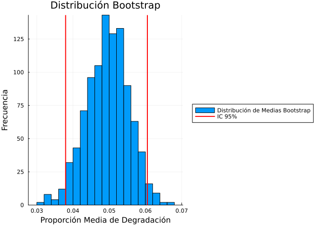

```julia
histogram(medias_bootstrap,
          label="Distribución de Medias Bootstrap",
          xlabel="Proporción Media de Degradación",
          ylabel="Frecuencia",
          title="Distribución Bootstrap",
          legend=:outerright)
vline!([limite_inferior, limite_superior], label="IC 95%", lw=2, color=:red, legend=:outerright)
```

De lo anterior se observa que la media original cae dentro del intervalo de confianza.

En términos de riesgo de pérdida de inventario, el límite superior del Intervalo representa el peor escenario razonable. Para una gestión de inventario segura, se debería planificar considerando que la pérdida podría llegar a ser tan alta como este valor, analogamente el límite inferior representa el mejor escenario.

# PARTE B: BOOSTRAP EN MACHINE LEARNING.

## 3.- Bootstrap y validación de modelos.

Se crea un dataset sintético para clasificación (degradado = 1, no degradado = 0) donde se usara una regresion logisitca siguiendo la siguiente regla logica: más temperatura, mas dias de almacenamiento y si el tipo de producto es perecedero, entonces hay mas probabilidad de degradación.

Esto permite controlar la verdadera relación y probar métodos.

```julia
n_obs = 150
df_logistica = DataFrame(
    temperatura = rand(Uniform(10, 20), n_obs),
    dias_almacenamiento = rand(1:20, n_obs),
    tipo_producto = rand(["perecedero", "no_perecedero"], n_obs)
)

prob_degradacion = 1 ./ (1 .+ exp.(-(-6 .+ 13 .* df_logistica.temperatura .+ 17 .* df_logistica.dias_almacenamiento .+ 19 .* (df_logistica.tipo_producto .== "perecedero"))))
df_logistica.degradado = [rand(Bernoulli(p)) for p in prob_degradacion]

println("--- Dataset para Regresión Logística (primeras 5 filas)---")
pretty_table(first(df_logistica, 5))
```

```
--- Dataset para Regresión Logística (primeras 5 filas)---
┌─────────────┬─────────────────────┬───────────────┬───────────┐
│ temperatura │ dias_almacenamiento │ tipo_producto │ degradado │
│     Float64 │               Int64 │        String │      Bool │
├─────────────┼─────────────────────┼───────────────┼───────────┤
│     15.4281 │                   8 │    perecedero │      true │
│     19.3674 │                  10 │ no_perecedero │      true │
│     11.7181 │                   8 │ no_perecedero │      true │
│     11.6848 │                   2 │ no_perecedero │      true │
│     16.2226 │                   8 │ no_perecedero │      true │
└─────────────┴─────────────────────┴───────────────┴───────────┘
```

Se usara Boostrap con 500 re-muestreos para poder visualizar la distribución de los coeficientes al ajustar un modelo de regresión logística.

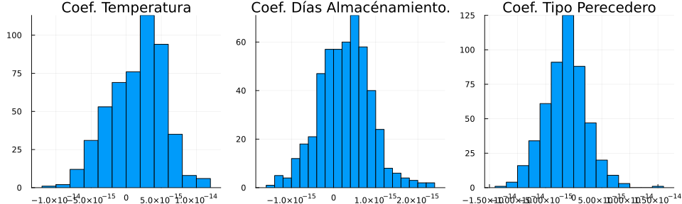

```julia
n_remuestreos_modelo = 500
coeficientes_bootstrap = zeros(n_remuestreos_modelo, 4)

for i in 1:n_remuestreos_modelo
    indices = rand(1:nrow(df_logistica), nrow(df_logistica))
    remuestra_df = df_logistica[indices, :]

    modelo_bs = glm(@formula(degradado ~ temperatura + dias_almacenamiento + tipo_producto), remuestra_df, Binomial(), LogitLink())

    coeficientes_bootstrap[i, :] = coef(modelo_bs)
end

p1 = histogram(coeficientes_bootstrap[:, 2], title="Coef. Temperatura", legend=false)
p2 = histogram(coeficientes_bootstrap[:, 3], title="Coef. Días Almacénamiento.", legend=false)
p3 = histogram(coeficientes_bootstrap[:, 4], title="Coef. Tipo Perecedero", legend=false)
plot(p1, p2, p3, layout=(1, 3), size=(1000, 300))
```

En resumen, el bootstrap ayuda a pasar de la temperatura tiene un coeficiente de 0.4 a es muy seguro de que el impacto de la temperatura está entre 0.3 y 0.5, cuantificando así la confianza en cada variable del modelo.

En la practica se recomienda usar Boostrap, ya que nos da una forma no paramétrica (no requiere supuestos fuertes, ni normalidad en los datos) de cuantificar incertidumbre.

## 4.- Bagging aplicado a inventarios.

Se entrenara primero un solo árbol de decisión al mismo dataset de regresión logistica.

```julia
X = select(df_logistica, [:temperatura, :dias_almacenamiento])
X.tipo_producto_num = (df_logistica.tipo_producto .== "perecedero") # Convertir a numérico
y = df_logistica.degradado

modelo_arbol_simple = DecisionTreeClassifier(max_depth=1)
DecisionTree.fit!(modelo_arbol_simple, Matrix(X), y)
predicciones_simple = DecisionTree.predict(modelo_arbol_simple, Matrix(X))
accuracy_simple = mean(predicciones_simple .== y)
println("Accuracy de un solo Árbol de Decisión: $(accuracy_simple)")
```

```
Accuracy de un solo Árbol de Decisión: 1.0
```

Ahora se entrenara un Random Forest al mismo dataset con 500 árboles de decisión en diferentes remuestras bootstrap y combinar sus predicciones, esto reduce varianza del estimador final (menos sensibilidad a datos particulares).

Cabe aclarar que en el Random Forest no solo es aplicar Bagging, pues en el Random Forest aparte de aplicar Bagging tambien se hace un submuestreo en las variables, es decir que cada arbol no se entrena con todas las variables predictoras, si no que con solo agunas, en este caso cada arbol se entrenara con dos de las tres variables predictoras (temperatura, dias de almacenamiento y tipo de producto), con esto se reduce la correlación entre árboles.

```julia
ensamble_bagging = RandomForestClassifier(n_trees=500, n_subfeatures=2)
DecisionTree.fit!(ensamble_bagging, Matrix(X), y)
predicciones_bagging = DecisionTree.predict(ensamble_bagging, Matrix(X))
accuracy_bagging = mean(predicciones_bagging .== y)
println("Accuracy del Ensamble Bagging, Random Forest (500 árboles): $(accuracy_bagging)")
```

```
Accuracy del Ensamble Bagging, Random Forest (500 árboles): 1.0
```

# PARTE C: PROBLEMA APLICADO: CONTROL DE INVENTARIOS CON DEGRADACIÓN POR TEMPERATURA.

Ahora se combinara todo en un caso mas realista:

Primero se generara para 200 lotes, la temperatura en °C en la que fue alamacenado el lote que sigue una distribucíón uniforme en el intervalo (15,25), tambien los dias de almacenamiento, que van de 5 a 60 dias, y finalmente la categoria del lote (congelado, refrigerado ó ambiente).

Luego se generara el porcentaje de pérdida, de la siguiente manera:

Por cada grado de temperatura que aumenta, el porcentaje de perdidas aumenta un 0.2%, por cada dia extra que permenece en almacenamiento, el porcentaje de perdida aumenta un 0.5%, el efecto de la categoria depende del tipo de categoria (congelado, refrigerado ó ambiente), finalmente se le agrega un ruido, y se asegura que el porcentaje de perdida este entre un 0% y 100%.

```julia
n_lotes = 200
df_perdidas = DataFrame(
    temperatura = rand(Uniform(15, 25), n_lotes), # °C
    tiempo_almacenamiento = rand(5:60, n_lotes), # días
    categoria = rand(["congelado", "refrigerado", "ambiente"], n_lotes)
)
# Regla de degradación: más temp y tiempo -> más pérdida. Categoría afecta.
efecto_categoria = map(c -> c == "congelado" ? -10 : (c == "refrigerado" ? 0 : 15), df_perdidas.categoria)
perdida_base = 0.2 .* df_perdidas.temperatura .+ 0.5 .* df_perdidas.tiempo_almacenamiento .+ efecto_categoria
ruido = rand(Normal(0, 5), n_lotes) # Incertidumbre aleatoria
df_perdidas.perdida_pct = clamp.(perdida_base .+ ruido, 0, 100) # Pérdida entre 0% y 100%

println("\n--- Dataset para el Problema Aplicado ---")
pretty_table(first(df_perdidas, 5))
```

```
--- Dataset para el Problema Aplicado ---
┌─────────────┬───────────────────────┬─────────────┬─────────────┐
│ temperatura │ tiempo_almacenamiento │   categoria │ perdida_pct │
│     Float64 │                 Int64 │      String │     Float64 │
├─────────────┼───────────────────────┼─────────────┼─────────────┤
│      17.547 │                    11 │    ambiente │     22.8225 │
│     17.7764 │                    28 │ refrigerado │     17.8176 │
│     23.6808 │                    52 │   congelado │     11.4484 │
│     23.7285 │                    12 │   congelado │     9.83449 │
│      23.577 │                    58 │   congelado │     24.5863 │
└─────────────┴───────────────────────┴─────────────┴─────────────┘
```

Ahora se entrenara un modelo de regresión lineal para predecir el porcentaje de pérdida.

```julia
modelo_regresion = lm(@formula(perdida_pct ~ temperatura + tiempo_almacenamiento + categoria), df_perdidas)
println("\n--- Modelo de Regresión Inicial ---")
display(modelo_regresion)
```

```
--- Modelo de Regresión Inicial ---
```

```
StatsModels.TableRegressionModel{LinearModel{GLM.LmResp{Vector{Float64}}, GLM.DensePredChol{Float64, LinearAlgebra.CholeskyPivoted{Float64, Matrix{Float64}, Vector{Int64}}}}, Matrix{Float64}}

perdida_pct ~ 1 + temperatura + tiempo_almacenamiento + categoria

Coefficients:
─────────────────────────────────────────────────────────────────────────────────────────
                             Coef.  Std. Error       t  Pr(>|t|)    Lower 95%   Upper 95%
─────────────────────────────────────────────────────────────────────────────────────────
(Intercept)              13.9524     2.46837      5.65    <1e-07    9.08425     18.8205
temperatura               0.284601   0.119421     2.38    0.0181    0.0490777    0.520125
tiempo_almacenamiento     0.452974   0.0213418   21.22    <1e-51    0.410883     0.495064
categoria: congelado    -22.9757     0.808746   -28.41    <1e-70  -24.5707     -21.3807
categoria: refrigerado  -13.5121     0.841097   -16.06    <1e-36  -15.1709     -11.8533
─────────────────────────────────────────────────────────────────────────────────────────
```

Se usara bootstrap para medir la incertidumbre del error del modelo (RMSE) y tambien para medir la incertidumbre del coeficiente de determinacion $R^2$.

```julia
n_remuestreos_final = 200
rmses_bootstrap = zeros(n_remuestreos_final)
r2s_bootstrap = zeros(n_remuestreos_final)

for i in 1:n_remuestreos_final
    indices = rand(1:nrow(df_perdidas), nrow(df_perdidas))
    remuestra_df = df_perdidas[indices, :]
     # Entrenar el modelo en el remuestreo
    modelo_bs = lm(@formula(perdida_pct ~ temperatura + tiempo_almacenamiento + categoria), remuestra_df)

    # a) Calcular y guardar RMSE (evaluado sobre el dataset original)
    predicciones = GLM.predict(modelo_bs, df_perdidas)
    error_cuadratico = (predicciones .- df_perdidas.perdida_pct).^2
    rmses_bootstrap[i] = sqrt(mean(error_cuadratico))
    # b) Calcular y guardar R² del modelo bootstrap
    r2s_bootstrap[i] = r2(modelo_bs)
end

# 4. Analizamos la distribución del RMSE
ic_rmse_95 = quantile(rmses_bootstrap, [0.025, 0.975])
ic_r2_95 = quantile(r2s_bootstrap, [0.025, 0.975])

println("\n--- Análisis de Incertidumbre del Modelo (Completo) ---")
println("Intervalo de confianza (95%) para el RMSE: [$(round(ic_rmse_95[1], digits=3)), $(round(ic_rmse_95[2], digits=3))]")
println("Intervalo de confianza (95%) para el R²:   [$(round(ic_r2_95[1], digits=3)), $(round(ic_r2_95[2], digits=3))]")
```

```
--- Análisis de Incertidumbre del Modelo (Completo) ---
Intervalo de confianza (95%) para el RMSE: [4.668, 4.812]
Intervalo de confianza (95%) para el R²:   [0.841, 0.896]
```

Como el intervalo de confianza del 95% del RMSE es [4.668, 4.812], esto significa que, al re-muestrear muchas veces los datos, el error típico de predicción del modelo se mantiene estable, entre 4.7 y 4.8 unidades, el cual es un intervalo muy estrecho, lo cual indica que el modelo es consistente: su error no cambia demasiado de una muestra a otra.

Analogamente como el intervalo de confianza del 95% del $R^2$ es [0.841, 0.896], esto significa que en el peor de los casos, el modelo explica un 84% de la variabilidad de la variable dependiente, y en el mejor de los casos, cerca del 90%. Es un rango alto y relativamente estrecho, lo que refuerza que el modelo tiene buen poder explicativo.

Finalmente para ver mejor la distribucion del (RMSE) y del $R^2$, se graficaran los histogramas y boxplots correspondiente a cada uno.

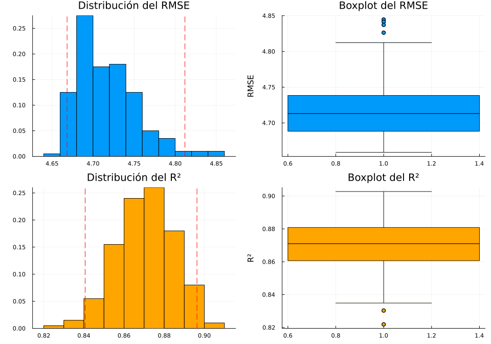

```julia
df_resultados_bs = DataFrame(RMSE = rmses_bootstrap, R2 = r2s_bootstrap)

# Gráfico 1: Histograma del RMSE
p_hist_rmse = histogram(df_resultados_bs.RMSE,
                        title="Distribución del RMSE",
                        legend=false,
                        normalize=:probability,
                        xlabel="")
vline!(p_hist_rmse, ic_rmse_95, color=:red, linestyle=:dash, label="IC 95%")

# Gráfico 2: Boxplot del RMSE
p_box_rmse = @df df_resultados_bs boxplot(:RMSE,
                                          title="Boxplot del RMSE",
                                          legend=false,
                                          ylabel="RMSE")

# Gráfico 3: Histograma del R²
p_hist_r2 = histogram(df_resultados_bs.R2,
                      title="Distribución del R²",
                      legend=false,
                      normalize=:probability,
                      color=:orange)
vline!(p_hist_r2, ic_r2_95, color=:red, linestyle=:dash, label="IC 95%")

# Gráfico 4: Boxplot del R²
p_box_r2 = @df df_resultados_bs boxplot(:R2,
                                        title="Boxplot del R²",
                                        legend=false,
                                        ylabel="R²",
                                        color=:orange)

# Se combinan los 4 gráficos en un solo layout
plot(p_hist_rmse, p_box_rmse, p_hist_r2, p_box_r2,
     layout=(2, 2),
     size=(1000, 700),
     left_margin=5Plots.mm)
```

Como la distribución del RMSE, es un poco simetrica y concentrada, esto significa que el error de predicción del modelo es bastante estable, como el rango del IC está entre 4.668 y 4.812, entonces el modelo se equivoca en promedio alrededor de ±5 puntos porcentuales de pérdida.

Tambien como el Boxplot del RMSE es una caja muy compacta, y casi no hay outliers, confirma que no existen escenarios en los que el modelo “explote” con errores muy altos.

Asi como el error de predicción del modelo es bajo y consistente, esto significa que las estimaciones del porcentaje de pérdida son confiables para tomar decisiones (ej. planear inventario extra para cubrir ~5% de error máximo esperado).

Analogamente como la distribución del R^2 está centrado alrededor de 0.87, entonces el modelo explica en promedio casi el 87% de la variabilidad en las pérdidas, como la distribución es estrecha, esto indica que el modelo casi siempre rinde parecido, independientemente de la muestra.

Tambien como el Boxplot es una caja pequeña y sin muchos valores atípicos extremos (solo 2), quiere decir que el poder explicativo del modelo es robusto.

Con lo cual el modelo capta la mayor parte de las causas que afectan el porcentaje de pérdida (temperatura, días de almacenamiento, tipo de producto, etc.), y rara vez baja de un desempeño alto.

## 5.- Conclusión.

Por ultimo se va a predecir el porcentaje de pérdida esperada considerando incertidumbre, para un producto refrigerado almacenado 10 días a 8°C.

```julia
#5. **Conclusión**
# Creamos el escenario que queremos predecir
escenario = DataFrame(temperatura=8, tiempo_almacenamiento=10, categoria="refrigerado")

# Generamos 200 predicciones, una por cada modelo bootstrap
predicciones_escenario = zeros(n_remuestreos_final)
for i in 1:n_remuestreos_final
    indices = rand(1:nrow(df_perdidas), nrow(df_perdidas))
    remuestra_df = df_perdidas[indices, :]
    modelo_bs = lm(@formula(perdida_pct ~ temperatura + tiempo_almacenamiento + categoria), remuestra_df)
    predicciones_escenario[i] = GLM.predict(modelo_bs, escenario)[1]
end

# Obtenemos un intervalo de predicción
intervalo_prediccion = quantile(predicciones_escenario, [0.025, 0.975])

println("\n--- Conclusión Práctica ---")
println("Para un producto refrigerado almacenado 10 días a 8°C:")
println("El intervalo de confianza al 95% para la pérdida por degradación es del $(round(intervalo_prediccion[1], digits=1))% al $(round(intervalo_prediccion[2], digits=1))%.")

println("Pregunta Final: ¿Cómo ayuda esto a diseñar políticas de inventario más seguras?")
println("Esta información es crucial. En lugar de basar una política de reabastecimiento en una única predicción (ej. se perderá el 7%), podemos usar el intervalo. Para ser conservadores (política segura), podríamos planificar asumiendo el peor caso del intervalo (pérdida del $(intervalo_prediccion[2])%).")
```

```
--- Conclusión Práctica ---
Para un producto refrigerado almacenado 10 días a 8°C:
El intervalo de confianza al 95% para la pérdida por degradación es del 4.0% al 10.0%.
Pregunta Final: ¿Cómo ayuda esto a diseñar políticas de inventario más seguras?
Esta información es crucial. En lugar de basar una política de reabastecimiento en una única predicción (ej. se perderá el 7%), podemos usar el intervalo. Para ser conservadores (política segura), podríamos planificar asumiendo el peor caso del intervalo (pérdida del 10.016097101601408%).
```

## 6.- Bibliografía:

1.- Efron, B. (1979). Bootstrap methods: Another look at the jackknife. The Annals of Statistics, 7(1), 1–26.

2.- Breiman, L. (1996). Bagging predictors. Machine Learning, 24(2), 123–140.

3.- Breiman, L. (2001). Random forests. Machine Learning, 45(1), 5–32.